# IMMERSE day 4: iteration and functions key

Casey O’Hara

2023-05-13

```r
library(tidyverse)
library(here)
```

## Challenge: reading in a bunch of files at once!

Look in the data folder. There is a file for each CA county with data on K-8 schools. Examine one file (let’s use Santa Barbara for our example) to get a sense of what’s in there. It is actually the `AER::CASchools` dataset, just broken down by county.

Now let’s read one in and examine some trends. First, let’s make graphical comparisons of certain variables by income. We can plot each variable individually, or pivot_longer some observations

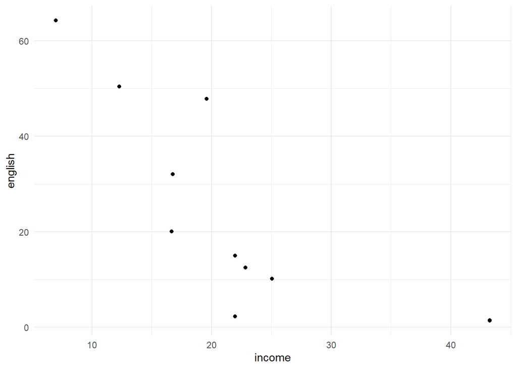

```r
sbc <- read_csv(here('county_data/santa_barbara.csv'))

ggplot(sbc, aes(x = income, y = english)) + ### try read, math scores, other vars
  geom_point() +
  theme_minimal()
```

OK, let’s summarize these variables across the county, and write them out.

```r
sbc_summary <- sbc %>%
  group_by(grades) %>%
  summarize(mean_inc = mean(income),
            mean_read = mean(read),
            mean_math = mean(math))
write_csv(sbc_summary, here('county_data_summary/santa_barbara.csv'))
```

## Now let’s do that across all 45 county files in our data folder!

Ugh! that sounds tedious. How can we make this less tedious?

### You do:

Fellows consider how to improve the process; give them time to think and write down, then discuss briefly; instructor writes as pseudocode.

The basic idea:

- For any given file name, read it in, process it, save it out.
- Different methods of iteration!

## Loops intro

For loops are a basic structure in most programming languages; *for* every element in a sequence, apply some amount of code.

```r
vec <- 1:20

for(x in vec) {
  print(x * 2)
}
```

```
## [1] 2
## [1] 4
## [1] 6
## [1] 8
## [1] 10
## [1] 12
## [1] 14
## [1] 16
## [1] 18
## [1] 20
## [1] 22
## [1] 24
## [1] 26
## [1] 28
## [1] 30
## [1] 32
## [1] 34
## [1] 36
## [1] 38
## [1] 40
```

```r
vec <- rnorm(n = 20, mean = 0, sd = 10)

### for each character element
month_vec <- month.name ### built in month names

for(m in month_vec) {
  x <- paste(m, '2023')
  print(x)
}
```

```
## [1] "January 2023"
## [1] "February 2023"
## [1] "March 2023"
## [1] "April 2023"
## [1] "May 2023"
## [1] "June 2023"
## [1] "July 2023"
## [1] "August 2023"
## [1] "September 2023"
## [1] "October 2023"
## [1] "November 2023"
## [1] "December 2023"
```

```r
### sequence along a vector, with the index of each element
for(i in seq_along(month_vec)) {
  m <- month_vec[i]
  y <- paste(m, 2023)
  print(y)
}
```

```
## [1] "January 2023"
## [1] "February 2023"
## [1] "March 2023"
## [1] "April 2023"
## [1] "May 2023"
## [1] "June 2023"
## [1] "July 2023"
## [1] "August 2023"
## [1] "September 2023"
## [1] "October 2023"
## [1] "November 2023"
## [1] "December 2023"
```

Why loops? Iteration can make short work of tedious tasks. Let’s make a loop over all our files, and learn some useful functions for working with files.

```r
file_vec1 <- list.files(here('county_data'))
file_vec2 <- list.files(here('county_data'), full.names = TRUE)
file_vec3 <- list.files(here('county_data'), full.names = TRUE, pattern = '.csv')

file_vec2[25]
```

```
## [1] "C:/Users/casey/Documents/github/immerse_day4_iter_and_fxns/county_data/sacramento.csv"
```

```r
basename(file_vec2[25])
```

```
## [1] "sacramento.csv"
```

```r
dirname(file_vec2[25])
```

```
## [1] "C:/Users/casey/Documents/github/immerse_day4_iter_and_fxns/county_data"
```

### You do (5 min):

Try to make a loop over all the counties; read in the file from the `data` folder and write out the results to the `data_clean` folder with the same base name. Start with pseudocode, then build from there.

```r
f_vec <- list.files(here('county_data'), full.names = TRUE)
for(f in f_vec) {
  ### f <- f_vec[1]
  cty_df <- read_csv(f, show_col_types = FALSE)

  cty_summary <- cty_df %>%
    group_by(grades) %>%
    summarize(mean_inc = mean(income),
              mean_read = mean(read),
              mean_math = mean(math))
  f_out <- here('county_data_summary', basename(f))

  write_csv(cty_summary, f_out)
}
```

## Functions intro

Write a simple function to take a number and square it. Then add some bells and whistles…

```r
square <- function(x) {
  y <- x^2
  return(y)
}

square(3); square(sqrt(10))
```

```
## [1] 9
```

```
## [1] 10
```

```r
square <- function(x, pow = 2) {
  y <- x^pow
  return(y)
}

square(3, pow = 5)
```

```
## [1] 243
```

Why functions?

- reuse a piece of code - and if you change the function, that change reflects through all uses
- put a human-readable name (usually a verb clause) to a chunk of code - communicate to collaborators and future you
- handy within loops and iteration functions (among other functions)

### You do:

Turn our code for Santa Barbara County data above into a function. Tell it a file, it reads and summarizes the file and then writes out a clean copy. Solicit student input - have them paste code into Slack or the Zoom chat.

```r
process_county <- function(f) {
  county_df <- read_csv(f, show_col_types = FALSE)

  county_summary <- county_df %>%
    group_by(grades) %>%
    summarize(mean_inc = mean(income),
              mean_read = mean(read),
              mean_math = mean(math))
  f_out <- here('county_data_summary', basename(f))
  write_csv(county_summary, f_out)

  return(county_summary)
}

### Test it out: first, delete all the files in county_data_summary then:
# process_county(f = here('county_data/santa_barbara.csv'))
```

Now write a loop to apply your function across all files.

```r
f_vec <- list.files(here('county_data'), full.names = TRUE)
# system.time({
for(f in f_vec) {
  x <- process_county(f = f)
  ### note, we don't do anything with x, so it is forgotten each new time
  ### through the loop!
}
# })
```

## lapply() function

lapply() is a built-in way to apply a function across all items in a sequence (list, vector, etc). It is usually faster and more efficient than a for loop, since it is implemented in C++ under the hood. There is also a parallelized version so you can take advantage of multiple processor cores simultaneously to speed things up.

```r
# ?lapply
system.time({
lapply(X = f_vec, FUN = process_county)
})
```

```
##    user  system elapsed
##    0.38    0.04    0.96
```

You might also investigate the `purrr` package, part of the `tidyverse` - `purrr::map()` is essentially the same as `lapply()`, but with more tidyverse-friendly features.

## One last `lapply()` example!

If `FUN` results in a data frame, then `lapply` results in a list of data frames - which can be bound together using `bind_rows()`.

```r
county_list <- lapply(f_vec,
                      FUN = read_csv,
                      show_col_types = FALSE) ### additional params to FUN

all_county_df <- bind_rows(county_list)

DT::datatable(all_county_df)
```

|  | district | school | county | grades | students | teachers | calworks | lunch | computer | expenditure | income | english | read | math |
| --- | --- | --- | --- | --- | --- | --- | --- | --- | --- | --- | --- | --- | --- | --- |
| 1 | 75119 | Sunol Glen Unified | ALAMEDA | KK-08 | 195 | 10.8999996185303 | 0.510200023651123 | 2.04080009460449 | 67 | 6384.9111328125 | 22.6900005340576 | 0 | 691.599975585938 | 690 |
| 2 | 61499 | Manzanita Elementary | Butte | KK-08 | 240 | 11.1499996185303 | 15.4167003631592 | 47.9166984558105 | 101 | 5099.380859375 | 9.82400035858154 | 4.58333349227905 | 660.5 | 661.900024414062 |
| 3 | 61549 | Thermalito Union Elementary | butte | KK-08 | 1550 | 82.9000015258789 | 55.032299041748 | 76.3226013183594 | 169 | 5501.95458984375 | 8.97799968719482 | 30.0000019073486 | 636.299987792969 | 650.900024414062 |
| 4 | 61457 | Golden Feather Union Elementary | butte | KK-08 | 243 | 14 | 36.475399017334 | 77.049201965332 | 85 | 7101.8310546875 | 8.97799968719482 | 0 | 651.900024414062 | 643.5 |
| 5 | 61523 | Palermo Union Elementary | Butte | KK-08 | 1335 | 71.5 | 33.1086006164551 | 78.427001953125 | 171 | 5235.98779296875 | 9.08033275604248 | 13.8576774597168 | 641.799987792969 | 639.900024414062 |
| 6 | 61382 | Bangor Union Elementary | Butte | KK-08 | 146 | 8 | 25.3425006866455 | 54.1096000671387 | 34 | 6231.6015625 | 7.10500001907349 | 0 | 646.099975585938 | 629.799987792969 |
| 7 | 61507 | Oroville City Elementary | butte | KK-08 | 3401 | 175.550003051758 | 52.219898223877 | 74.2723007202148 | 560 | 5489.5888671875 | 11.2661247253418 | 16.1717147827148 | 641.5 | 638.099975585938 |
| 8 | 61572 | Mark Twain Union Elementary | calaveras | KK-08 | 777 | 36.8499984741211 | 12.9886999130249 | 39.8487014770508 | 148 | 5482.67724609375 | 13.2430000305176 | 1.15830111503601 | 663.400024414062 | 650.200012207031 |
| 9 | 61705 | Knightsen Elementary | contra costa | KK-08 | 353 | 19.9799995422363 | 8.67210006713867 | 33.0623016357422 | 8 | 5238.39208984375 | 14.6529998779297 | 5.38243627548218 | 636.599975585938 | 633.5 |
| 10 | 61655 | Brentwood Union Elementary | Contra Costa | KK-08 | 3519 | 175.300003051758 | 5.54129981994629 | 29.7812004089355 | 789 | 5105.734375 | 15.0270004272461 | 15.4589366912842 | 655.400024414062 | 645.799987792969 |

[output cut: 410 more lines]

```r
write_csv(all_county_df, here('data/ca_schools.csv'))
```